# Simulation Project

Summer 2022, Vladyslava Rybka

# Simulation Study 1: Significance of Regression

## Introduction

In this simulation study we will investigate the significance of regression test. We will simulate from two different models:

1. The **“significant”** model

$$Y_i = \beta_0 + \beta_1 x_{i1} + \beta_2 x_{i2} + \beta_3 x_{i3} +
\epsilon_i$$

where $\epsilon_i \sim N(0, \sigma^2)$ and

- $\beta_0 = 3$,
- $\beta_1 = 1$,
- $\beta_2 = 1$,
- $\beta_3 = 1$.
2. The **“non-significant”** model

$$Y_i = \beta_0 + \beta_1 x_{i1} + \beta_2 x_{i2} + \beta_3 x_{i3} +
\epsilon_i$$

where $\epsilon_i \sim N(0, \sigma^2)$ and

- $\beta_0 = 3$,
- $\beta_1 = 0$,
- $\beta_2 = 0$,
- $\beta_3 = 0$.

For both, we will consider a sample size of $25$ and three possible levels of noise. That is, three values of $\sigma$.

- $n = 25$
- $\sigma \in (1, 5, 10)$

The simulation is used to obtain an empirical distribution for each of the following values, for each of the three values of $\sigma$, for both models.

- The **$F$ statistic** for the significance of regression test.
- The **p-value** for the significance of regression test
- **$R^2$**

## Methods

Set the seed for reproducibility and import the data:

```r
set.seed(15)
library(readr)
library(knitr)
data1 = read_csv("study_1.csv")
```

Assigning the variables used for simulation:

```r
n = 25
sigma1  = 1
sigma2  = 5
sigma3 = 10
beta_0_s = 3
beta_1_s = 1
beta2_s = 1
beta3_s = 1
beta_0_ns = 3
beta_1_ns = 0
beta2_ns = 0
beta3_ns = 0
num_sims = 2500
num_models = 6

x1 = data1$x1
x2 = data1$x2
x3 = data1$x3
```

Creating vectors to store F statistic, p value and R2 for all six models.

- Model 1: significant model with sigma = 1
- Model 2: significant model with sigma = 5
- Model 3: significant model with sigma = 10
- Model 4: non-significant model with sigma = 1
- Model 5: non-significant model with sigma = 5
- Model 6: non-significant model with sigma = 10

```r
f1 = rep(0, num_sims)
p1 = rep(0, num_sims)
r2_1 = rep(0, num_sims)

f2 = rep(0, num_sims)
p2 = rep(0, num_sims)
r2_2 = rep(0, num_sims)

f3 = rep(0, num_sims)
p3 = rep(0, num_sims)
r2_3 = rep(0, num_sims)

f4 = rep(0, num_sims)
p4 = rep(0, num_sims)
r2_4 = rep(0, num_sims)

f5 = rep(0, num_sims)
p5 = rep(0, num_sims)
r2_5 = rep(0, num_sims)

f6 = rep(0, num_sims)
p6 = rep(0, num_sims)
r2_6 = rep(0, num_sims)
```

Simulating fitted regression and calculating F statistic, p value and R2 for all six models:

```r
#Model 1: significant model with sigma = 1
for (i in 1:num_sims) {
    epsilon = rnorm(n = 25, mean = 0, sd = 1)
    y = beta_0_s + beta_1_s * x1 + beta2_s * x2 + beta3_s * x3 + epsilon
    model_1 = lm(y ~ x1 + x2 + x3)
    f1[i] = summary(model_1)$fstatistic[1]
    p1[i] = pf(summary(model_1)$fstatistic[1], summary(model_1)$fstatistic[2],
               summary(model_1)$fstatistic[3], lower.tail = FALSE)
    r2_1[i] = summary(model_1)$r.squared
}

#Model 2: significant model with sigma = 5
for (i in 1:num_sims) {
    epsilon = rnorm(n = 25, mean = 0, sd = 5)
    y = beta_0_s + beta_1_s * x1 + beta2_s * x2 + beta3_s * x3 + epsilon
    model_2 = lm(y ~ x1 + x2 + x3)
    f2[i] = summary(model_2)$fstatistic[1]
    p2[i] = pf(summary(model_2)$fstatistic[1], summary(model_2)$fstatistic[2],
               summary(model_2)$fstatistic[3], lower.tail = FALSE)
    r2_2[i] = summary(model_2)$r.squared
}

# Model 3: significant model with sigma = 10
for (i in 1:num_sims) {
    epsilon = rnorm(n = 25, mean = 0, sd = 10)
    y = beta_0_s + beta_1_s * x1 + beta2_s * x2 + beta3_s * x3 + epsilon
    model_3 = lm(y ~ x1 + x2 + x3)
    f3[i] = summary(model_3)$fstatistic[1]
    p3[i] = pf(summary(model_3)$fstatistic[1], summary(model_3)$fstatistic[2],
               summary(model_3)$fstatistic[3], lower.tail = FALSE)
    r2_3[i] = summary(model_3)$r.squared
}

# Model 4: non-significant model with sigma = 1
for (i in 1:num_sims) {
    epsilon = rnorm(n = 25, mean = 0, sd = 1)
    y = beta_0_ns + beta_1_ns * x1 + beta2_ns * x2 + beta3_ns * x3 + epsilon
    model_4 = lm(y ~ x1 + x2 + x3)
    f4[i] = summary(model_4)$fstatistic[1]
    p4[i] = pf(summary(model_4)$fstatistic[1], summary(model_4)$fstatistic[2],
               summary(model_4)$fstatistic[3], lower.tail = FALSE)
    r2_4[i] = summary(model_4)$r.squared
}

# Model 5: non-significant model with sigma = 5
for (i in 1:num_sims) {
    epsilon = rnorm(n = 25, mean = 0, sd = 5)
    y = beta_0_ns + beta_1_ns * x1 + beta2_ns * x2 + beta3_ns * x3 + epsilon
    model_5 = lm(y ~ x1 + x2 + x3)
    f5[i] = summary(model_5)$fstatistic[1]
    p5[i] = pf(summary(model_5)$fstatistic[1], summary(model_5)$fstatistic[2],
               summary(model_5)$fstatistic[3], lower.tail = FALSE)
    r2_5[i] = summary(model_5)$r.squared
}

# Model 6: non-significant model with sigma = 10
for (i in 1:num_sims) {
    epsilon = rnorm(n = 25, mean = 0, sd = 10)
    y = beta_0_ns + beta_1_ns * x1 + beta2_ns * x2 + beta3_ns * x3 + epsilon
    model_6 = lm(y ~ x1 + x2 + x3)
    f6[i] = summary(model_6)$fstatistic[1]
    p6[i] = pf(summary(model_6)$fstatistic[1], summary(model_6)$fstatistic[2],
               summary(model_6)$fstatistic[3], lower.tail = FALSE)
    r2_6[i] = summary(model_6)$r.squared
}
```

Generating mean and variance for all the values of interest:

```r
Model = c("Significant, sigma = 1","Significant, sigma = 5","Significant, sigma = 10",
         "Non-Significant, sigma = 1","Non-Significant, sigma = 5","Non-Significant, sigma = 10")
F_mean = c(mean(f1),mean(f2),mean(f3),mean(f4),mean(f5),mean(f6))
F_var = c(var(f1),var(f2),var(f3),var(f4),var(f5),var(f6))
p_mean = c(mean(p1),mean(p2),mean(p3),mean(p4),mean(p5),mean(p6))
p_var = c(var(p1),var(p2),var(p3),var(p4),var(p5),var(p6))
R2_mean = c(mean(r2_1),mean(r2_2),mean(r2_3),mean(r2_4),mean(r2_5),mean(r2_6))
R2_var = c(var(r2_1),var(r2_2),var(r2_3),var(r2_4),var(r2_5),var(r2_6))
results = data.frame(Model,F_mean,F_var,p_mean,p_var,R2_mean,R2_var)
```

Code used for generating table and plots in the results section:

```r
kable(results, digits=3)
```

```r
n = 2500
p = 3
# F statistic sigma = 1
par(mfrow = c(1, 2))
hist(f1, main = "Significant, sigma = 1", border = "darkblue", xlab = "F Statistic", prob = TRUE)
x = f1
curve(df(x, df1 = p, df2 = n-p), col = "firebrick", add = TRUE, lwd = 3)
hist(f4, main = "Non-significant, sigma = 1", border = "darkblue", xlab = "F Statistic", prob = TRUE)
x = f4
curve(df(x, df1 = p, df2 = n-p), col = "firebrick", add = TRUE, lwd = 3)

# F statistic sigma = 5
par(mfrow = c(1, 2))
hist(f2, main = "Significant, sigma = 5", border = "darkblue", xlab = "F Statistic", prob = TRUE)
x = f2
curve(df(x, df1 = p, df2 = n-p), col = "firebrick", add = TRUE, lwd = 3)
hist(f5, main = "Non-significant, sigma = 5", border = "darkblue", xlab = "F Statistic", prob = TRUE)
x = f5
curve(df(x, df1 = p, df2 = n-p), col = "firebrick", add = TRUE, lwd = 3)

# F statistic sigma = 10
par(mfrow = c(1, 2))
hist(f3, main = "Significant, sigma = 10", border = "darkblue", xlab = "F Statistic", prob = TRUE)
x = f3
curve(df(x, df1 = p, df2 = n-p), col = "firebrick", add = TRUE, lwd = 3)
hist(f6, main = "Non-significant, sigma = 10", border = "darkblue", xlab = "F Statistic", prob = TRUE)
x = f6
curve(df(x, df1 = p, df2 = n-p), col = "firebrick", add = TRUE, lwd = 3)

# p-value sigma = 1
par(mfrow = c(1, 2))
hist(p1, main = "Significant, sigma = 1", border = "darkblue", xlab = "p-value", prob = TRUE)
hist(p4, main = "Non-significant, sigma = 1", border = "darkblue", xlab = "p-value", prob = TRUE)

# p-value sigma = 5
par(mfrow = c(1, 2))
hist(p2, main = "Significant, sigma = 5", border = "darkblue", xlab = "p-value", prob = TRUE)
hist(p5, main = "Non-significant, sigma = 5", border = "darkblue", xlab = "p-value", prob = TRUE)

# p-value sigma = 10
par(mfrow = c(1, 2))
hist(p3, main = "Significant, sigma = 10", border = "darkblue", xlab = "p-value", prob = TRUE)
hist(p6, main = "Non-significant, sigma = 10", border = "darkblue",xlab = "p-value",prob = TRUE)

# R^2 sigma = 1
par(mfrow = c(1, 2))
hist(r2_1, main = "Significant, sigma = 1", border = "darkblue", xlab = "R^2", prob = TRUE)
hist(r2_4, main = "Non-significant, sigma = 1", border = "darkblue", xlab = "R^2", prob = TRUE)

# R^2 sigma = 5
par(mfrow = c(1, 2))
hist(r2_2, main = "Significant, sigma = 5", border = "darkblue", xlab = "R^2", prob = TRUE)
hist(r2_5, main = "Non-significant, sigma = 5", border = "darkblue", xlab = "R^2", prob = TRUE)

# R^2 sigma = 10
par(mfrow = c(1, 2))
hist(r2_3, main = "Significant, sigma = 10", border = "darkblue", xlab = "R^2", prob = TRUE)
hist(r2_6, main = "Non-significant, sigma = 10",border = "darkblue", xlab = "R^2", prob = TRUE)
```

## Results

Summary of calculated F statistic, p value and R2 for significant and non-significant models at different sigmas:

| Model | F_mean | F_var | p_mean | p_var | R2_mean | R2_var |
| --- | --- | --- | --- | --- | --- | --- |
| Significant, sigma = 1 | 41.480 | 289.354 | 0.000 | 0.000 | 0.840 | 0.002 |
| Significant, sigma = 5 | 2.718 | 4.268 | 0.211 | 0.055 | 0.253 | 0.017 |
| Significant, sigma = 10 | 1.462 | 1.635 | 0.409 | 0.084 | 0.157 | 0.011 |
| Non-Significant, sigma = 1 | 1.111 | 1.008 | 0.495 | 0.084 | 0.126 | 0.008 |
| Non-Significant, sigma = 5 | 1.084 | 0.968 | 0.504 | 0.083 | 0.123 | 0.008 |
| Non-Significant, sigma = 10 | 1.116 | 1.088 | 0.499 | 0.084 | 0.126 | 0.009 |

Graphical summary of the results:

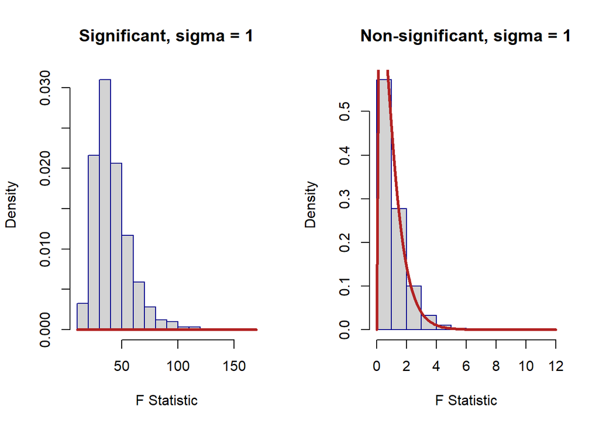

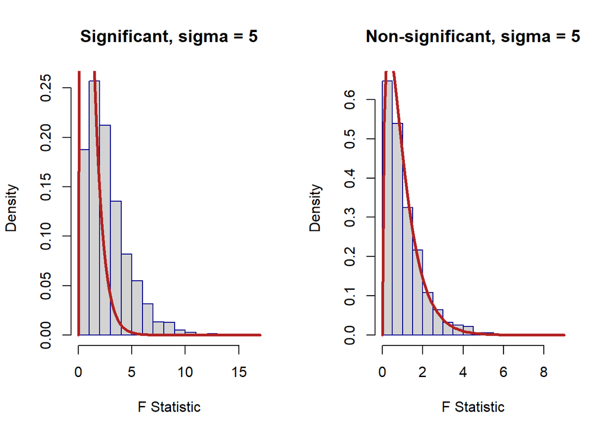

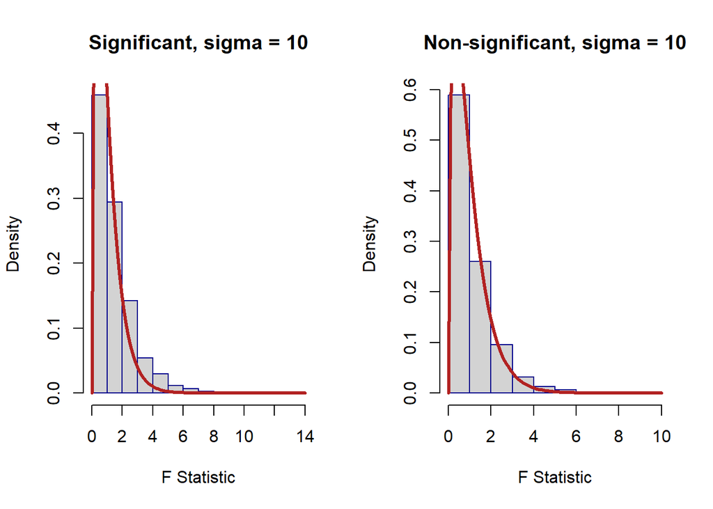

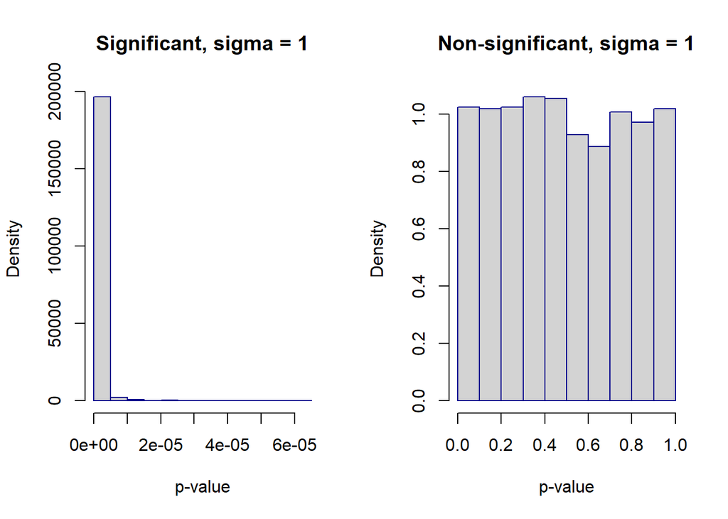

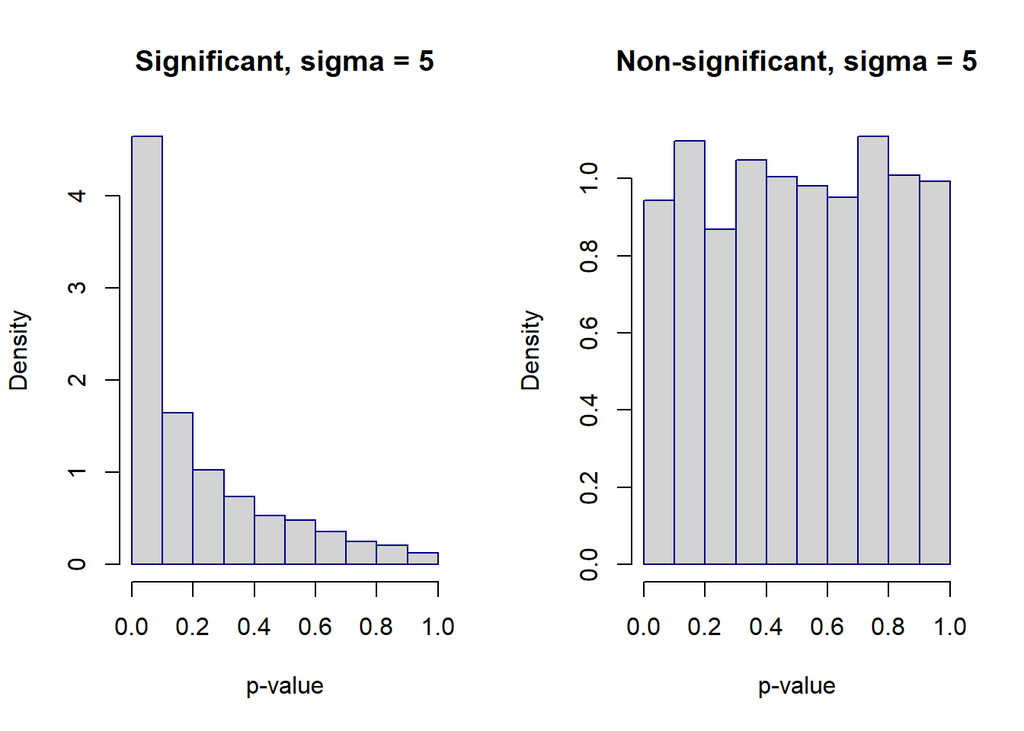

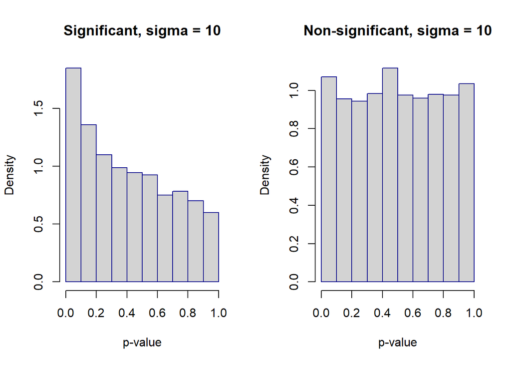

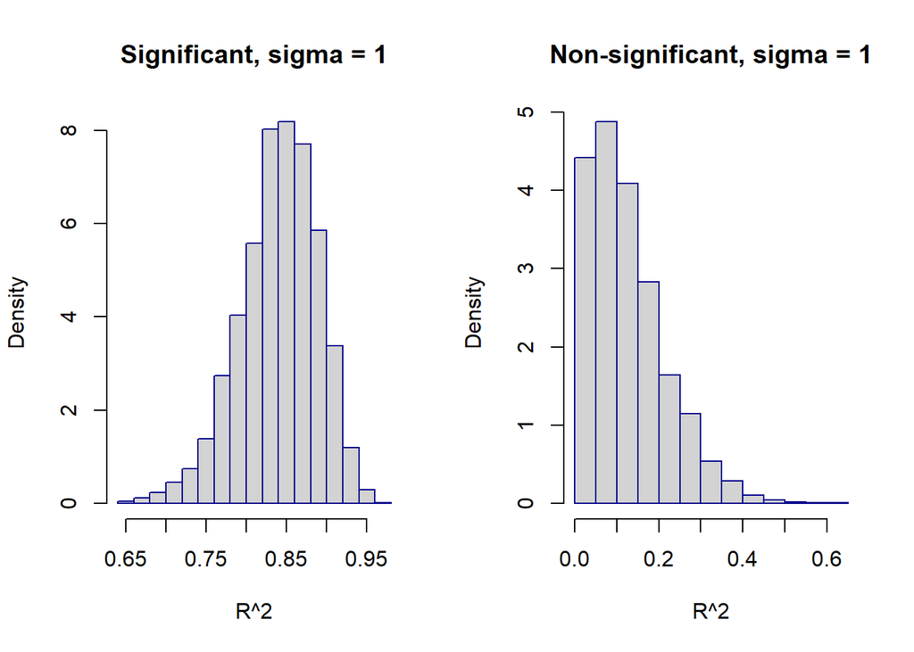

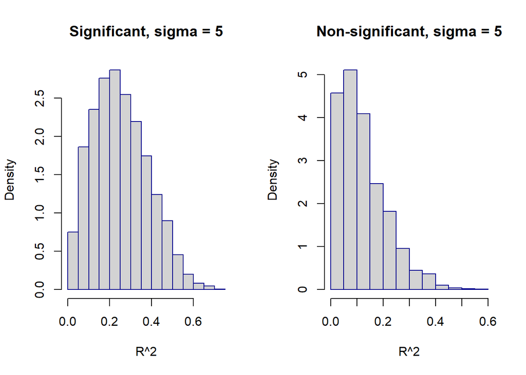

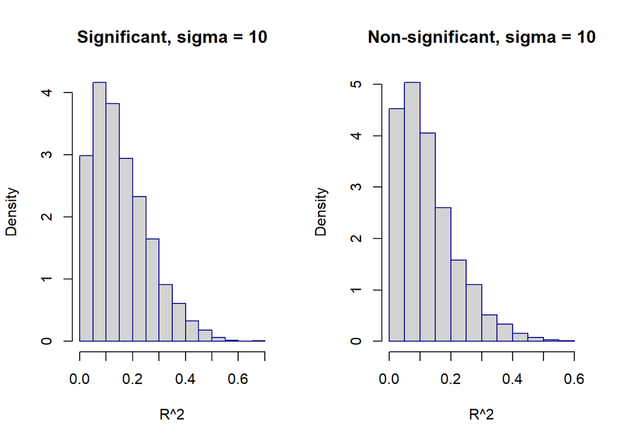

## Discussion

- The f-statistic for significant models doesn’t seem to align with the true distribution curve, which is especially true when sigma = 1, indicating that the model is significant. As the value for sigma increases the distribution becomes closer to the true F distribution.
- The p-values for the non-significant models appear to have uniform distribution between 0 and 1. While p-values for significant models appear to be closer to zero, especially for lower sigma, indicating the significance of the model.
- For the significant models lower sigma values correspond to higher R^2 values, since sigma influences the amount of noise the model has. At lower sigma values, the distribution appears to be normal, but as sigma increases, the mean gets closer to zero, with the distribution resembling more of that in non-significant model.

# Simulation Study 2: Using RMSE for Selection?

## Introduction

In this simulation study we will investigate how well RMSE can be used to select the “best” model . Since splitting the data is random, we don’t expect it to work correctly each time. We could get unlucky. But averaged over many attempts, we should expect it to select the appropriate model.

We will simulate from the model

$$Y_i = \beta_0 + \beta_1 x_{i1} + \beta_2 x_{i2} + \beta_3 x_{i3} +
\beta_4 x_{i4} + \beta_5 x_{i5} + \beta_6 x_{i6} + \epsilon_i$$

where $\epsilon_i \sim N(0, \sigma^2)$ and

- $\beta_0 = 0$,
- $\beta_1 = 3$,
- $\beta_2 = -4$,
- $\beta_3 = 1.6$,
- $\beta_4 = -1.1$,
- $\beta_5 = 0.7$,
- $\beta_6 = 0.5$.

We will consider a sample size of $500$ and three possible levels of noise. That is, three values of $\sigma$.

- $n = 500$
- $\sigma \in (1, 2, 4)$

The data found in `study_2.csv` is used for the values of the predictors. These should be kept constant for the entirety of this study. The `y` values in this data are a blank placeholder.

Each simulation the data is randomly split into train and test sets of equal sizes (250 observations for training, 250 observations for testing).

For each, fit **nine** models, with forms:

- `y ~ x1`
- `y ~ x1 + x2`
- `y ~ x1 + x2 + x3`
- `y ~ x1 + x2 + x3 + x4`
- `y ~ x1 + x2 + x3 + x4 + x5`
- `y ~ x1 + x2 + x3 + x4 + x5 + x6`, the correct form of the model as noted above
- `y ~ x1 + x2 + x3 + x4 + x5 + x6 + x7`
- `y ~ x1 + x2 + x3 + x4 + x5 + x6 + x7 + x8`
- `y ~ x1 + x2 + x3 + x4 + x5 + x6 + x7 + x8 + x9`

For each model, calculate Train and Test RMSE.

$$\text{RMSE}(\text{model, data}) = \sqrt{\frac{1}{n} \sum_{i = 1}^{n}(y_i
- \hat{y}_i)^2}$$

## Methods

Set the seed for reproducibility and import the data:

```r
set.seed(15)
library(readr)
library(knitr)
data2 = read_csv("study_2.csv")
```

Assigning the variables used for simulation:

```r
beta_0 = 0
beta_1 = 3
beta_2 = -4
beta_3 = 1.6
beta_4 = -1.1
beta_5 = 0.7
beta_6 = 0.5
n = 500
sim_size = 1000

x0 = rep(0,n)
x1 = data2$x1
x2 = data2$x2
x3 = data2$x3
x4 = data2$x4
x5 = data2$x5
x6 = data2$x6
x7 = data2$x7
x8 = data2$x8
x9 = data2$x9

m1_train = rep(0,n)
m2_train = rep(0,n)
m3_train = rep(0,n)
m4_train = rep(0,n)
m5_train = rep(0,n)
m6_train = rep(0,n)
m7_train = rep(0,n)
m8_train = rep(0,n)
m9_train = rep(0,n)
m1_test = rep(0,n)
m2_test = rep(0,n)
m3_test = rep(0,n)
m4_test = rep(0,n)
m5_test = rep(0,n)
m6_test = rep(0,n)
m7_test = rep(0,n)
m8_test = rep(0,n)
m9_test = rep(0,n)
```

Function used to calculate RMSE:

```r
rmse  = function(actual, estimated) {
  sqrt(mean((actual - estimated) ^ 2))
}
```

Generating simulation models and RMSE for sigma = 1

```r
for (i in 1:sim_size) {
  eps = rnorm(n, mean = 0, sd = 1)
  data2$y = beta_0 * x0  + beta_1 * x1 + beta_2 * x2 + beta_3 * x3 + beta_4 * x4
  + beta_5 * x5 + beta_6 * x6 + eps

  split = sample(1:nrow(data2), 250)
  train_data = data2[split, ]
  test_data = data2[-split, ]
  model1 = lm(y ~ x1, data = train_data)
  model2 = lm(y ~ x1 + x2, data = train_data)
  model3 = lm(y ~ x1 + x2 + x3, data = train_data)
  model4 = lm(y ~ x1 + x2 + x3 + x4, data = train_data)
  model5 = lm(y ~ x1 + x2 + x3 + x4 + x5, data = train_data)
  model6 = lm(y ~ x1 + x2 + x3 + x4 + x5 + x6, data = train_data)
  model7 = lm(y ~ x1 + x2 + x3 + x4 + x5 + x6 + x7, data = train_data)
  model8 = lm(y ~ x1 + x2 + x3 + x4 + x5 + x6 + x7 + x8, data = train_data)
  model9 = lm(y ~ x1 + x2 + x3 + x4 + x5 + x6 + x7 + x8 + x9, data = train_data)

  m1_train[i] = rmse(train_data$y, predict(model1, train_data))
  m2_train[i] = rmse(train_data$y, predict(model2, train_data))
  m3_train[i] = rmse(train_data$y, predict(model3, train_data))
  m4_train[i] = rmse(train_data$y, predict(model4, train_data))
  m5_train[i] = rmse(train_data$y, predict(model5, train_data))
  m6_train[i] = rmse(train_data$y, predict(model6, train_data))
  m7_train[i] = rmse(train_data$y, predict(model7, train_data))
  m8_train[i] = rmse(train_data$y, predict(model8, train_data))
  m9_train[i] = rmse(train_data$y, predict(model9, train_data))
  m1_test[i] = rmse(test_data$y, predict(model1, test_data))
  m2_test[i] = rmse(test_data$y, predict(model2, test_data))
  m3_test[i] = rmse(test_data$y, predict(model3, test_data))
  m4_test[i] = rmse(test_data$y, predict(model4, test_data))
  m5_test[i] = rmse(test_data$y, predict(model5, test_data))
  m6_test[i] = rmse(test_data$y, predict(model6, test_data))
  m7_test[i] = rmse(test_data$y, predict(model7, test_data))
  m8_test[i] = rmse(test_data$y, predict(model8, test_data))
  m9_test[i] = rmse(test_data$y, predict(model9, test_data))
}
  train_1 = data.frame(m1_train,m2_train,m3_train,m4_train,m5_train,
                       m6_train,m7_train,m8_train,m9_train)
  test_1 = data.frame(m1_test,m2_test,m3_test,m4_test,m5_test,m6_test,
                      m7_test,m8_test,m9_test)
```

Generating simulation models and RMSE for sigma = 2

```r
for (i in 1:sim_size) {
  eps = rnorm(n, mean = 0, sd = 2)
  data2$y = beta_0 * x0  + beta_1 * x1 + beta_2 * x2 + beta_3 * x3 + beta_4 * x4
  + beta_5 * x5 + beta_6 * x6 + eps

  split = sample(1:nrow(data2), 250)
  train_data = data2[split, ]
  test_data = data2[-split, ]
  model1 = lm(y ~ x1, data = train_data)
  model2 = lm(y ~ x1 + x2, data = train_data)
  model3 = lm(y ~ x1 + x2 + x3, data = train_data)
  model4 = lm(y ~ x1 + x2 + x3 + x4, data = train_data)
  model5 = lm(y ~ x1 + x2 + x3 + x4 + x5, data = train_data)
  model6 = lm(y ~ x1 + x2 + x3 + x4 + x5 + x6, data = train_data)
  model7 = lm(y ~ x1 + x2 + x3 + x4 + x5 + x6 + x7, data = train_data)
  model8 = lm(y ~ x1 + x2 + x3 + x4 + x5 + x6 + x7 + x8, data = train_data)
  model9 = lm(y ~ x1 + x2 + x3 + x4 + x5 + x6 + x7 + x8 + x9, data = train_data)

  m1_train[i] = rmse(train_data$y, predict(model1, train_data))
  m2_train[i] = rmse(train_data$y, predict(model2, train_data))
  m3_train[i] = rmse(train_data$y, predict(model3, train_data))
  m4_train[i] = rmse(train_data$y, predict(model4, train_data))
  m5_train[i] = rmse(train_data$y, predict(model5, train_data))
  m6_train[i] = rmse(train_data$y, predict(model6, train_data))
  m7_train[i] = rmse(train_data$y, predict(model7, train_data))
  m8_train[i] = rmse(train_data$y, predict(model8, train_data))
  m9_train[i] = rmse(train_data$y, predict(model9, train_data))
  m1_test[i] = rmse(test_data$y, predict(model1, test_data))
  m2_test[i] = rmse(test_data$y, predict(model2, test_data))
  m3_test[i] = rmse(test_data$y, predict(model3, test_data))
  m4_test[i] = rmse(test_data$y, predict(model4, test_data))
  m5_test[i] = rmse(test_data$y, predict(model5, test_data))
  m6_test[i] = rmse(test_data$y, predict(model6, test_data))
  m7_test[i] = rmse(test_data$y, predict(model7, test_data))
  m8_test[i] = rmse(test_data$y, predict(model8, test_data))
  m9_test[i] = rmse(test_data$y, predict(model9, test_data))
}
  train_2 = data.frame(m1_train,m2_train,m3_train,m4_train,m5_train,
                       m6_train,m7_train,m8_train,m9_train)
  test_2 = data.frame(m1_test,m2_test,m3_test,m4_test,m5_test,m6_test,
                      m7_test,m8_test,m9_test)
```

Generating simulation models and RMSE for sigma = 4

```r
for(i in 1:sim_size) {
  eps = rnorm(n, mean = 0, sd = 4)
  data2$y = beta_0 * x0  + beta_1 * x1 + beta_2 * x2 + beta_3 * x3 + beta_4 * x4
  + beta_5 * x5 + beta_6 * x6 + eps

  split = sample(1:nrow(data2), 250)
  train_data = data2[split,]
  test_data = data2[-split,]
  model1 = lm(y ~ x1, data = train_data)
  model2 = lm(y ~ x1 + x2, data = train_data)
  model3 = lm(y ~ x1 + x2 + x3, data = train_data)
  model4 = lm(y ~ x1 + x2 + x3 + x4, data = train_data)
  model5 = lm(y ~ x1 + x2 + x3 + x4 + x5, data = train_data)
  model6 = lm(y ~ x1 + x2 + x3 + x4 + x5 + x6, data = train_data)
  model7 = lm(y ~ x1 + x2 + x3 + x4 + x5 + x6 + x7, data = train_data)
  model8 = lm(y ~ x1 + x2 + x3 + x4 + x5 + x6 + x7 + x8, data = train_data)
  model9 = lm(y ~ x1 + x2 + x3 + x4 + x5 + x6 + x7 + x8 + x9, data = train_data)

  m1_train[i] = rmse(train_data$y, predict(model1, train_data))
  m2_train[i] = rmse(train_data$y, predict(model2, train_data))
  m3_train[i] = rmse(train_data$y, predict(model3, train_data))
  m4_train[i] = rmse(train_data$y, predict(model4, train_data))
  m5_train[i] = rmse(train_data$y, predict(model5, train_data))
  m6_train[i] = rmse(train_data$y, predict(model6, train_data))
  m7_train[i] = rmse(train_data$y, predict(model7, train_data))
  m8_train[i] = rmse(train_data$y, predict(model8, train_data))
  m9_train[i] = rmse(train_data$y, predict(model9, train_data))
  m1_test[i] = rmse(test_data$y, predict(model1, test_data))
  m2_test[i] = rmse(test_data$y, predict(model2, test_data))
  m3_test[i] = rmse(test_data$y, predict(model3, test_data))
  m4_test[i] = rmse(test_data$y, predict(model4, test_data))
  m5_test[i] = rmse(test_data$y, predict(model5, test_data))
  m6_test[i] = rmse(test_data$y, predict(model6, test_data))
  m7_test[i] = rmse(test_data$y, predict(model7, test_data))
  m8_test[i] = rmse(test_data$y, predict(model8, test_data))
  m9_test[i] = rmse(test_data$y, predict(model9, test_data))
}
  train_3 = data.frame(m1_train,m2_train,m3_train,m4_train,m5_train,
                       m6_train,m7_train,m8_train,m9_train)
  test_3 = data.frame(m1_test,m2_test,m3_test,m4_test,m5_test,m6_test,
                      m7_test,m8_test,m9_test)
```

Code used for generating tables and plots in the results section:

```r
mean_train_1 = apply(train_1, 2, mean)
mean_test_1 = apply(test_1, 2, mean)
Model = c("Model 1", "Model 2", "Model 3", "Model 4", "Model 5","Model 6",
          "Model 7","Model 8","Model 9")
df1 = data.frame(Model, mean_train_1, mean_test_1)
row.names(df1) = NULL
kable(df1, col.names = c('Model', 'Train RMSE', 'Test RMSE'),
      caption = "Average Train and Test RMSE when sigma = 1", digits=3)

mean_train_2 = apply(train_2, 2, mean)
mean_test_2 = apply(test_2, 2, mean)
df2 = data.frame(Model, mean_train_2, mean_test_2)
row.names(df2) = NULL
kable(df2, col.names = c('Model', 'Train RMSE', 'Test RMSE'),
      caption = "Average Train and Test RMSE when sigma = 2", digits=3)

mean_train_3 = apply(train_3, 2, mean)
mean_test_3 = apply(test_3, 2, mean)
df3 = data.frame(Model, mean_train_3, mean_test_3)
row.names(df3) = NULL
kable(df3, col.names = c('Model', 'Train RMSE', 'Test RMSE'),
      caption = "Average Train and Test RMSE when sigma = 4", digits=3)
```

```r
par(mfrow = c(1, 2))
m = c(1,2,3,4,5,6,7,8,9)
plot(mean_train_1 ~ m, data = train_1,
     xlab = "Model size", ylab = "RMSE",
     main = "Train Data, sigma = 1",
     pch  = 20, cex  = 3, col = "lightcoral",
     xlim = c(1, 9), ylim = c(0, 5))

plot(mean_test_1 ~ m, data = test_1,
     xlab = "Model size", ylab = "RMSE",
     main = "Test Data, sigma = 1",
     pch  = 20, cex  = 3, col = "lightcoral",
     xlim = c(1, 9), ylim = c(0, 5))

par(mfrow = c(1, 2))
m = c(1,2,3,4,5,6,7,8,9)
plot(mean_train_2 ~ m, data = train_2,
     xlab = "Model size", ylab = "RMSE",
     main = "Train Data, sigma = 2",
     pch  = 20, cex  = 3, col = "lightcoral",
     xlim = c(1, 9), ylim = c(0, 5))

plot(mean_test_2 ~ m, data = test_2,
     xlab = "Model size", ylab = "RMSE",
     main = "Test Data, sigma = 2",
     pch  = 20, cex  = 3, col = "lightcoral",
     xlim = c(1, 9), ylim = c(0, 5))

par(mfrow = c(1, 2))
m = c(1,2,3,4,5,6,7,8,9)
plot(mean_train_3 ~ m, data = train_3,
     xlab = "Model size", ylab = "RMSE",
     main = "Train Data, sigma = 4",
     pch  = 20, cex  = 3, col = "lightcoral",
     xlim = c(1, 9), ylim = c(0, 5))

plot(mean_test_3 ~ m, data = test_3,
     xlab = "Model size", ylab = "RMSE",
     main = "Test Data, sigma = 4",
     pch  = 20, cex  = 3, col = "lightcoral",
     xlim = c(1, 9), ylim = c(0, 5))
```

## Results

Average Train and Test RMSE when sigma = 1

| Model | Train RMSE | Test RMSE |
| --- | --- | --- |
| Model 1 | 2.311 | 2.324 |
| Model 2 | 1.117 | 1.131 |
| Model 3 | 0.325 | 0.331 |
| Model 4 | 0.000 | 0.000 |
| Model 5 | 0.000 | 0.000 |
| Model 6 | 0.000 | 0.000 |
| Model 7 | 0.000 | 0.000 |
| Model 8 | 0.000 | 0.000 |
| Model 9 | 0.000 | 0.000 |

Average Train and Test RMSE when sigma = 2

| Model | Train RMSE | Test RMSE |
| --- | --- | --- |
| Model 1 | 2.305 | 2.330 |
| Model 2 | 1.117 | 1.132 |
| Model 3 | 0.326 | 0.331 |
| Model 4 | 0.000 | 0.000 |
| Model 5 | 0.000 | 0.000 |
| Model 6 | 0.000 | 0.000 |
| Model 7 | 0.000 | 0.000 |
| Model 8 | 0.000 | 0.000 |
| Model 9 | 0.000 | 0.000 |

Average Train and Test RMSE when sigma = 4

| Model | Train RMSE | Test RMSE |
| --- | --- | --- |
| Model 1 | 2.311 | 2.323 |
| Model 2 | 1.117 | 1.132 |
| Model 3 | 0.325 | 0.331 |
| Model 4 | 0.000 | 0.000 |
| Model 5 | 0.000 | 0.000 |
| Model 6 | 0.000 | 0.000 |
| Model 7 | 0.000 | 0.000 |
| Model 8 | 0.000 | 0.000 |
| Model 9 | 0.000 | 0.000 |

Graphical summary of the results:

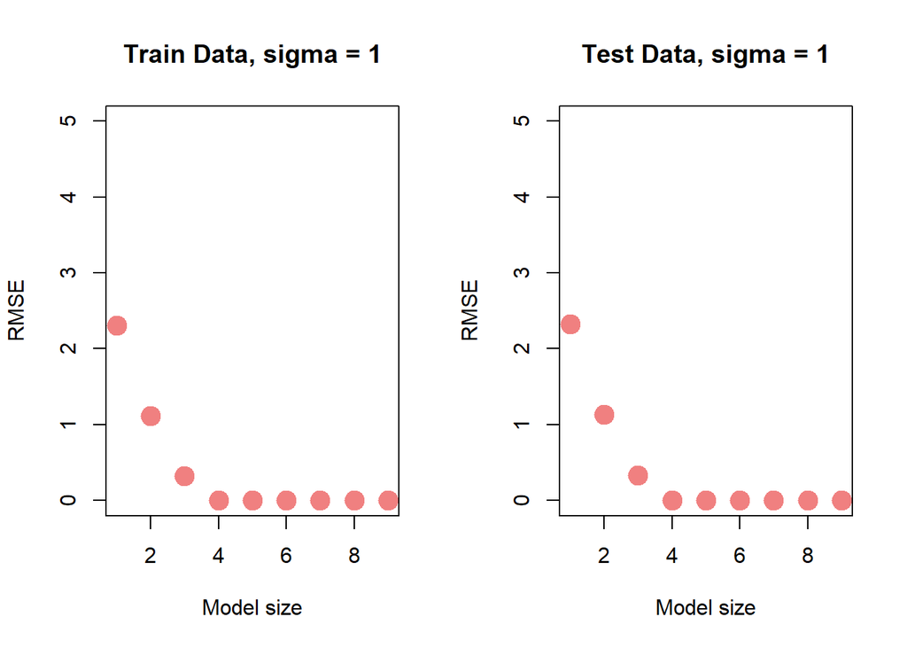

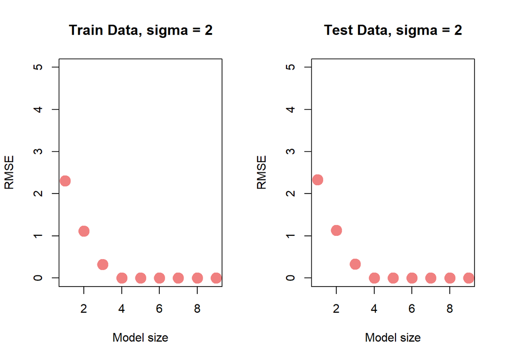

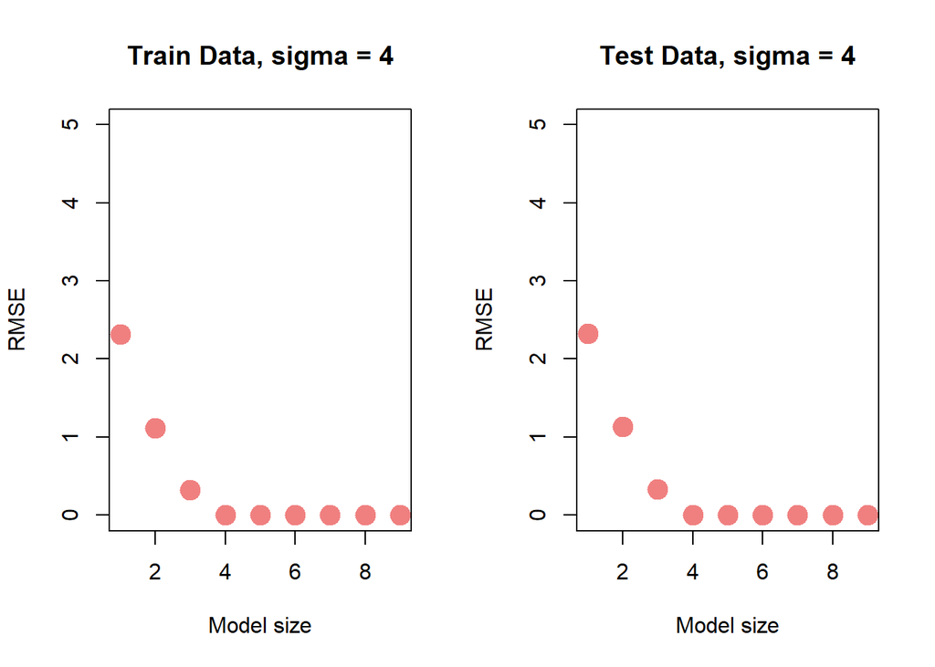

# Simulation Study 3: Power

## Introduction

In this simulation study we will investigate the **power** of the significance of regression test for simple linear regression.

$$H_0: \beta_{1} = 0 \ \text{vs} \ H_1: \beta_{1} \neq 0$$

We had defined the *significance* level, $\alpha$, to be the probability of a Type I error.

$$\alpha = P[\text{Reject } H_0 \mid H_0 \text{ True}] = P[\text{Type I
Error}]$$

Similarly, the probability of a Type II error is often denoted using $\beta$; however, this should not be confused with a regression parameter.

$$\beta = P[\text{Fail to Reject } H_0 \mid H_1 \text{ True}] =
P[\text{Type II Error}]$$

*Power* is the probability of rejecting the null hypothesis when the null is not true, that is, the alternative is true and $\beta_{1}$ is non-zero.

$$\text{Power} = 1 - \beta = P[\text{Reject } H_0 \mid H_1 \text{ True}]$$

Essentially, power is the probability that a signal of a particular strength will be detected. Many things affect the power of a test. In this case, some of those are:

- Sample Size, $n$
- Signal Strength, $\beta_1$
- Noise Level, $\sigma$
- Significance Level, $\alpha$

We’ll investigate the first three.

To do so we will simulate from the model

$$Y_i = \beta_0 + \beta_1 x_i + \epsilon_i$$

where $\epsilon_i \sim N(0, \sigma^2)$.

For simplicity, we will let $\beta_0 = 0$, thus $\beta_1$ is essentially controlling the amount of “signal.” We will then consider different signals, noises, and sample sizes:

- $\beta_1 \in (-2, -1.9, -1.8, \ldots, -0.1, 0, 0.1, 0.2, 0.3, \ldots 1.9, 2)$
- $\sigma \in (1, 2, 4)$
- $n \in (10, 20, 30)$

We will hold the significance level constant at $\alpha = 0.05$.

The following code is used to generate the predictor values, `x`: values for different sample sizes.

```r
x_values = seq(0, 5, length = n)
```

To estimate the power with these simulations, and some $\alpha$, use

$$\hat{\text{Power}} = \hat{P}[\text{Reject } H_0 \mid H_1 \text{ True}] =
\frac{\text{ Tests Rejected}}{\text{ Simulations}}$$

## Methods

Assigning the variables used for simulation:

```r
beta_0  = 0
beta_1  = seq(-2,2, by = 0.1)
sigma = c(1,2,4)
sample_size = c(10,20,30)
num_sims = 1000
size = length(sample_size) * length(beta_1)

df1 = data.frame("sample_size" = rep(0,size),"beta_1" = rep(0,size),"power" = rep(0,size))
df2 = data.frame("sample_size" = rep(0,size),"beta_1" = rep(0,size),"power" = rep(0,size))
df3 = data.frame("sample_size" = rep(0,size),"beta_1" = rep(0,size),"power" = rep(0,size))
```

Generating simulations and calculating power:

```r
# simulation for each sigma
for(c in 1:length(sigma))
{
  sigma_val  = sigma[c]
  row = 1
  # simulation for each sample size
  for (size_count in 1:length(sample_size))
  {
    n = sample_size[size_count]
    x = seq(0, 5, length = n)
    # simulation for each beta_1
    for (beta_1_count in 1:length(beta_1))
    {
      reject = 0
      power = 0
      beta_1_value = beta_1[beta_1_count]

      for (sim_count in 1:num_sims)
      {
        eps = rnorm(n, mean = 0, sd = sigma_val)
        y = beta_0 + beta_1_value * x + eps

        fit = lm(y ~ x)
        p_value = summary(fit)$coefficients[2, "Pr(>|t|)"]

        if (p_value < 0.05) {
          reject = reject + 1
        }
      }

      power = reject / num_sims
      # storing values for each simulation
      if (c == 1) {
        df1[row, "sample_size"] = n
        df1[row, "beta_1"] = beta_1_value
        df1[row, "power"] = power }

      if (c == 2) {
        df2[row, "sample_size"] = n
        df2[row, "beta_1"] = beta_1_value
        df2[row, "power"] = power }

      if (c == 3) {
        df3[row, "sample_size"] = n
        df3[row, "beta_1"] = beta_1_value
        df3[row, "power"] = power }
      row = row + 1
}}}
```

Code used for generating plots in the results section:

```r
par(mfrow = c(1,3))
plot(subset(df1,sample_size == 10)$beta_1,subset(df1,sample_size == 10)
     $power,col="blue",cex=1.5,xlab="beta_1", ylab="Power", main="n = 10")
lines(subset(df1,sample_size == 10)$beta_1,subset(df1,sample_size == 10)
      $power,col="orange",lwd=1)
plot(subset(df1,sample_size == 20)$beta_1,subset(df1,sample_size == 20)
     $power,col="blue",cex=1.5,xlab="beta_1", ylab="Power", main="n = 20")
lines(subset(df1,sample_size == 20)$beta_1,subset(df1,sample_size == 20)
      $power,col="orange",lwd=1)
plot(subset(df1,sample_size == 30)$beta_1,subset(df1,sample_size == 30)
     $power,col="blue",cex=1.5,xlab="beta_1", ylab="Power", main="n = 30")
lines(subset(df1,sample_size == 30)$beta_1,subset(df1,sample_size == 30)
      $power,col="orange",lwd=1)
```

```r
par(mfrow = c(1,3))
plot(subset(df2,sample_size == 10)$beta_1,subset(df2,sample_size == 10)
     $power,col="blue",cex=1.5,xlab="beta_1", ylab="Power", main="n = 10")
lines(subset(df2,sample_size == 10)$beta_1,subset(df2,sample_size == 10)
      $power,col="orange",lwd=1)
plot(subset(df2,sample_size == 20)$beta_1,subset(df2,sample_size == 20)
     $power,col="blue",cex=1.5,xlab="beta_1", ylab="Power", main="n = 20")
lines(subset(df2,sample_size == 20)$beta_1,subset(df2,sample_size == 20)
      $power,col="orange",lwd=1)
plot(subset(df2,sample_size == 30)$beta_1,subset(df2,sample_size == 30)
     $power,col="blue",cex=1.5,xlab="beta_1", ylab="Power", main="n = 30")
lines(subset(df2,sample_size == 30)$beta_1,subset(df2,sample_size == 30)
      $power,col="orange",lwd=1)
```

```r
par(mfrow = c(1,3))
plot(subset(df3,sample_size == 10)$beta_1,subset(df3,sample_size == 10)
     $power,col="blue",cex=1.5,xlab="beta_1", ylab="Power", main="n = 10")
lines(subset(df3,sample_size == 10)$beta_1,subset(df3,sample_size == 10)
      $power,col="orange",lwd=1)
plot(subset(df3,sample_size == 20)$beta_1,subset(df3,sample_size == 20)
     $power,col="blue",cex=1.5,xlab="beta_1", ylab="Power", main="n = 20")
lines(subset(df3,sample_size == 20)$beta_1,subset(df3,sample_size == 20)
      $power,col="orange",lwd=1)
plot(subset(df3,sample_size == 30)$beta_1,subset(df3,sample_size == 30)
     $power,col="blue",cex=1.5,xlab="beta_1", ylab="Power", main="n = 30")
lines(subset(df3,sample_size == 30)$beta_1,subset(df3,sample_size == 30)
      $power,col="orange",lwd=1)
```

## Results

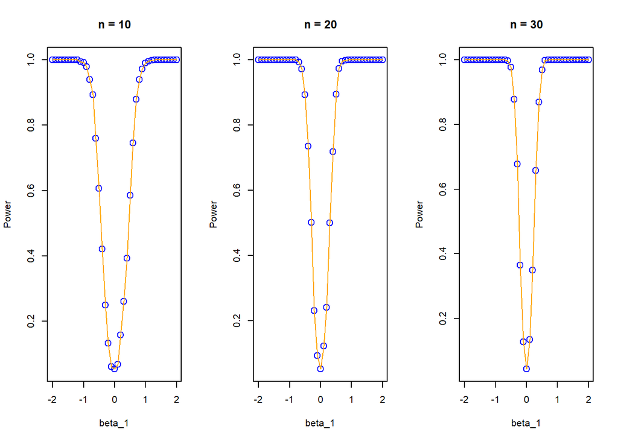

Power vs beta 1 for sigma = 1

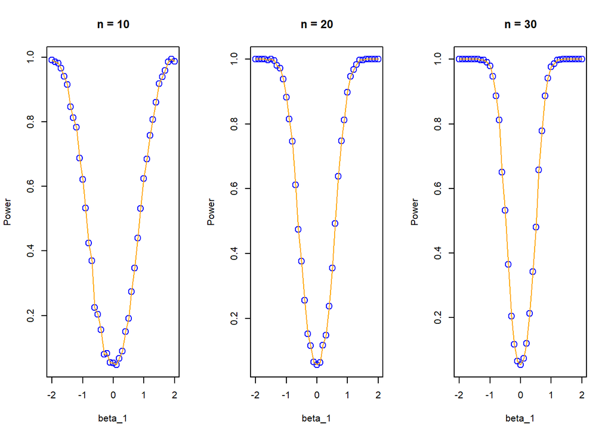

Power vs beta 1 for sigma = 2

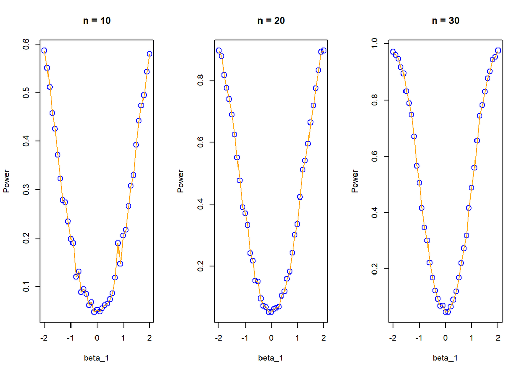

Power vs beta 1 for sigma = 4